# Misc lighting calculations

Ben Anderson (b.anderson@soton.ac.uk, `@dataknut`)

Last run at: 2019-05-10 15:57:20

# 1 Get GREEN Grid Lighting Data

Get Carsten’s re-weighted lighting profile data - derived from (Anderson et al. 2018)

```r
ggLightDT <- data.table::fread("~/Dropbox/Work/Otago_CfS_Ben/Students/CarstenDortans_MSc/Writing bursary/Lighting.csv")

skimr::skim(ggLightDT)
```

```
## Skim summary statistics
##  n obs: 10376945
##  n variables: 3
##
## ── Variable type:character ──────────────────────────────────────────────────────────────────────────────────────────
##    variable missing complete        n min max empty n_unique
##  r_dateTime       0 10376945 10376945  19  19     0   526920
##
## ── Variable type:integer ────────────────────────────────────────────────────────────────────────────────────────────
##  variable missing complete        n    mean    sd p0     p25     p50
##        V1       0 10376945 10376945 5188473 3e+06  1 2594237 5188473
##      p75  p100     hist
##  7782709 1e+07 ▇▇▇▇▇▇▇▇
##
## ── Variable type:numeric ────────────────────────────────────────────────────────────────────────────────────────────
##  variable missing complete        n      mean    sd p0 p25 p50        p75
##    powerW       0 10376945 10376945 9118290.6 2e+07  0   0   0 8346812.79
##     p100     hist
##  3.3e+08 ▇▁▁▁▁▁▁▁
```

```r
head(ggLightDT)
```

```
##    V1          r_dateTime  powerW
## 1:  1 2015-04-01 00:00:00 5835851
## 2:  2 2015-04-01 00:01:00 5874919
## 3:  3 2015-04-01 00:02:00 5835851
## 4:  4 2015-04-01 00:03:00 5835851
## 5:  5 2015-04-01 00:04:00 5835851
## 6:  6 2015-04-01 00:05:00 5835851
```

Check that the datetimes are NZ time otherwise we won’t be comparing the same half-hours.

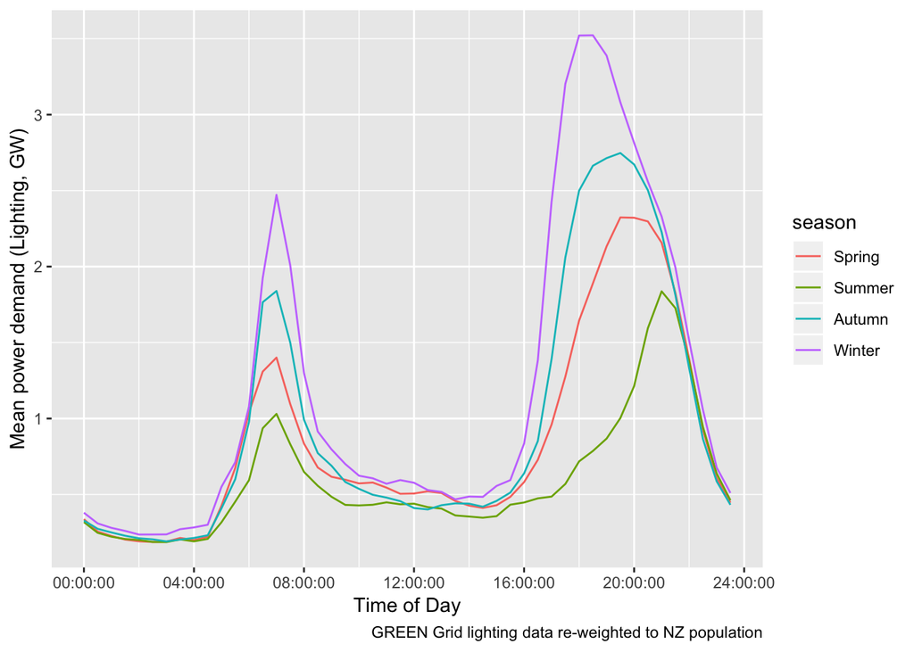

```r
ggLightDT <- ggLightDT[, r_dateTime := lubridate::as_datetime(r_dateTime)]
ggLightDT$V1 <- NULL # how did that get there?
ggLightDT <- ggLightDT[, hms := hms::as.hms(r_dateTime)]
ggLightDT <- ggLightDT[, halfHour := hms::trunc_hms(hms, 60*30)]

ggLightDT <- GREENGridData::addNZSeason(ggLightDT)
plotDT <- ggLightDT[, .(meanGW = mean(powerW/10000000)), keyby = .(halfHour, season)]
p <- ggplot2::ggplot(plotDT, aes(x = halfHour, y = meanGW, colour = season)) +
  geom_line() +
  labs(x = "Time of Day",
       y = "Mean power demand (Lighting, GW)",
       caption = "GREEN Grid lighting data re-weighted to NZ population")
p
```

Looks OK. This is because `hms::as.hms()` cleverly converts `r_dateTime` which it assumes to be UTC (it is) into local time. Without telling us…

Now convert that to half-hourly GWh for comparison with EA data.

```r
# do this before aggregating
ggLightDT <- ggLightDT[, powerWh := powerW/60] # cos it's per minute
ggLightDT <- ggLightDT[, consumptionGWh := powerWh/1000000000]

# need to aggregate from 1 min to (all) half hours
ggLightDT <- ggLightDT[, halfHourDate := lubridate::floor_date(r_dateTime, "30 mins")]
dt <- ggLightDT[, .(consumptionGWh = sum(consumptionGWh)), keyby = .(halfHourDate, halfHour, season)]

# now get the mean
plotGG_DT <- dt[, .(MeanGWh = mean(consumptionGWh)), keyby = .(halfHour, season)]

# check
message("Sum of GWh before agg = ", sum(ggLightDT$consumptionGWh))
```

```
## Sum of GWh before agg = 1577
```

```r
message("Sum of GWh after agg = ", sum(dt$consumptionGWh))
```

```
## Sum of GWh after agg = 1577
```

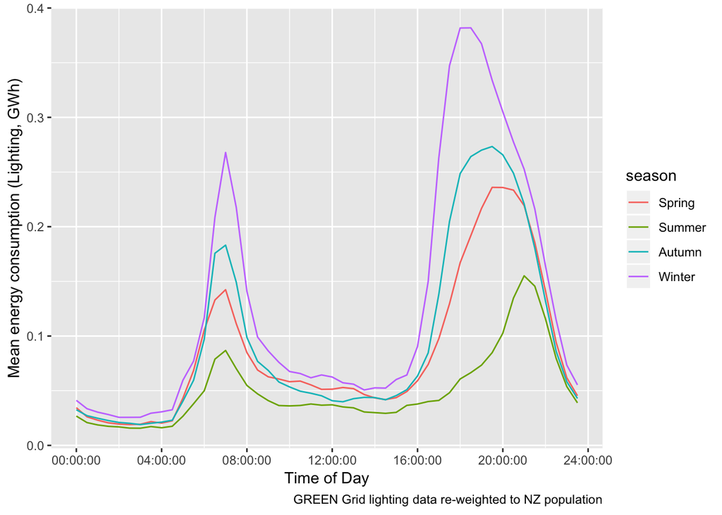

```r
p <- ggplot2::ggplot(plotGG_DT, aes(x = halfHour, y = MeanGWh, colour = season)) +
  geom_line() +
  labs(x = "Time of Day",
       y = "Mean energy consumption (Lighting, GWh)",
       caption = "GREEN Grid lighting data re-weighted to NZ population")
p
```

# 2 Get EA Generation data for 2015

Get the 2015 Generation data from the EA (igores distributed gen - solar as not really relevant to evening peaks). Data pre-downloaded from https://www.emi.ea.govt.nz/Wholesale/Datasets/Generation/Generation_MD & cleaned.

```r
eaPath <- "~/Data/NZ_GREENGrid/ea/"

fList <- data.table::as.data.table(list.files(eaPath))

f2015 <- fList[V1 %like% "2015" & V1 %like% "long"]
f2015 <- f2015[, fullName := paste0(eaPath, V1)]
ea2015GenDT <- data.table::data.table() # data bucket

# load them all in one go very fast
ea2015GenDT = rbindlist(lapply(f2015$fullName, fread))

skimr::skim(ea2015GenDT)
```

```
## Skim summary statistics
##  n obs: 1273500
##  n variables: 14
##
## ── Variable type:character ──────────────────────────────────────────────────────────────────────────────────────────
##      variable missing complete       n min max empty n_unique
##     Fuel_Code       0  1273500 1273500   3   6     0        7
##      Gen_Code       0  1273500 1273500   3  15     0       65
##      Nwk_Code       0  1273500 1273500   4   4     0       24
##      POC_Code       0  1273500 1273500   7   7     0       63
##         rDate       0  1273500 1273500  10  10     0      365
##     rDateTime       0  1273500 1273500   0  20 50940    17521
##     Site_Code       0  1273500 1273500   3   3     0       63
##     Tech_Code       0  1273500 1273500   3   5     0        5
##   Time_Period       0  1273500 1273500   3   4     0       50
##  Trading_date       0  1273500 1273500  10  10     0      365
##
## ── Variable type:integer ────────────────────────────────────────────────────────────────────────────────────────────
##  variable missing complete       n     mean       sd   p0   p25   p50
##     month       0  1273500 1273500     6.53     3.45    1     4     7
##     rTime   50940  1222560 1273500 43200    24936.13  900 22050 43200
##      year       0  1273500 1273500  2015        0    2015  2015  2015
##    p75  p100     hist
##     10    12 ▇▅▇▃▅▇▅▇
##  64350 85500 ▇▇▇▇▇▇▇▇
##   2015  2015 ▁▁▁▇▁▁▁▁
##
## ── Variable type:numeric ────────────────────────────────────────────────────────────────────────────────────────────
##  variable missing complete       n     mean       sd p0     p25      p50
##       kWh   50940  1222560 1273500 33373.31 49994.08  0 5178.98 17288.55
##    p75  p100     hist
##  42794 4e+05 ▇▂▁▁▁▁▁▁
```

```r
head(ea2015GenDT)
```

```
##    Site_Code POC_Code Nwk_Code  Gen_Code Fuel_Code Tech_Code Trading_date
## 1:       ANI  MAT1101     BOPD aniwhenua     Hydro     Hydro   2015-01-01
## 2:       ANI  MAT1101     BOPD aniwhenua     Hydro     Hydro   2015-01-02
## 3:       ANI  MAT1101     BOPD aniwhenua     Hydro     Hydro   2015-01-03
## 4:       ANI  MAT1101     BOPD aniwhenua     Hydro     Hydro   2015-01-04
## 5:       ANI  MAT1101     BOPD aniwhenua     Hydro     Hydro   2015-01-05
## 6:       ANI  MAT1101     BOPD aniwhenua     Hydro     Hydro   2015-01-06
##    Time_Period     kWh rTime      rDate            rDateTime month year
## 1:         TP1 3682.54   900 2015-01-01 2015-01-01T00:15:00Z     1 2015
## 2:         TP1 4179.41   900 2015-01-02 2015-01-02T00:15:00Z     1 2015
## 3:         TP1 3820.13   900 2015-01-03 2015-01-03T00:15:00Z     1 2015
## 4:         TP1 3544.18   900 2015-01-04 2015-01-04T00:15:00Z     1 2015
## 5:         TP1 3550.79   900 2015-01-05 2015-01-05T00:15:00Z     1 2015
## 6:         TP1 3612.30   900 2015-01-06 2015-01-06T00:15:00Z     1 2015
```

Now do the same process of checking and aggregating.

```r
ea2015GenDT <- ea2015GenDT[, r_dateTime := lubridate::as_datetime(rDateTime)]
ea2015GenDT <- ea2015GenDT[, r_dateTime := lubridate::force_tz(r_dateTime, tzone = "Pacific/Auckland")] # got to force it

ea2015GenDT <- ea2015GenDT[, hms := hms::as.hms(r_dateTime)]
ea2015GenDT <- ea2015GenDT[, halfHour := hms::trunc_hms(hms, 60*30)]

ea2015GenDT <- GREENGridData::addNZSeason(ea2015GenDT)

# make GWh
ea2015GenDT <- ea2015GenDT[, consumptionGWh := kWh/1000000]

# add up to total GWh for eachhalf hour (currently it's per gen site/fuel)
aggea2015GenDT <- ea2015GenDT[, .(consumptionGWh = sum(consumptionGWh, na.rm = TRUE)), # avoid NAs in dates (DST breaks) & kWh
                              keyby = .(season, r_dateTime, halfHour)]

# check
message("Sum of GWh = ", sum(aggea2015GenDT$consumptionGWh))
```

```
## Sum of GWh = 40800.874669309
```

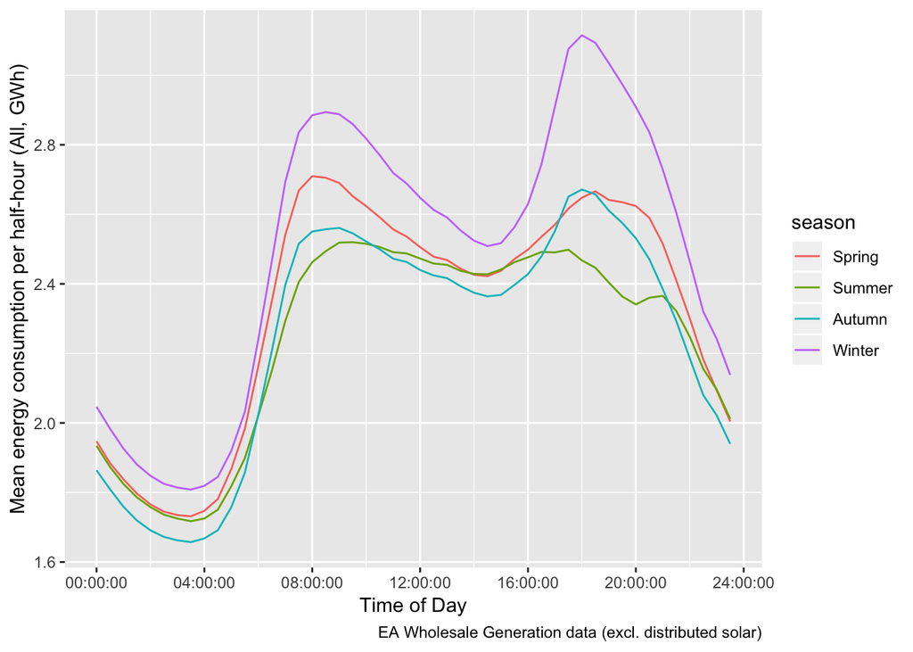

```r
# now re-create plotDT for the mean
plotEA_DT <- aggea2015GenDT[!is.na(r_dateTime), # avoid the single broken datetime as it messes with the plot
                            .(MeanGWh = mean(consumptionGWh)), keyby = .(halfHour, season)]
p <- ggplot2::ggplot(plotEA_DT, aes(x = halfHour, y = MeanGWh, colour = season)) +
  geom_line() +
  labs(x = "Time of Day",
       y = "Mean energy consumption per half-hour (All, GWh)",
       caption = "EA Wholesale Generation data (excl. distributed solar)")
p
```

# 3 Lighting as a % of total consumption

So now we need to plot the contribution of lighting to this.

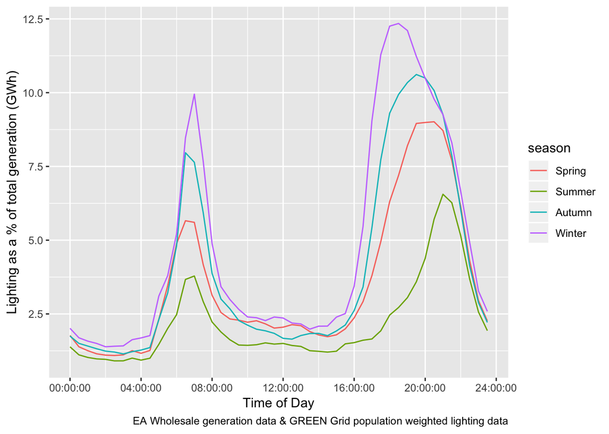

```r
setkey(plotEA_DT, season, halfHour)
setkey(plotGG_DT, season, halfHour)

plotEA_DT <- plotEA_DT[,eaMeanGWh := MeanGWh]
plotGG_DT <- plotGG_DT[, lightingMeanGWh := MeanGWh]

plotDT <- plotEA_DT[!is.na(MeanGWh)][plotGG_DT] #get rid of the bloody DST breaks
plotDT <- plotDT[, pc_lighting := 100*(lightingMeanGWh/eaMeanGWh)]

p <- ggplot2::ggplot(plotDT, aes(x = halfHour, y = pc_lighting, colour = season)) +
  geom_line() +
  labs(x = "Time of Day",
       y = "Lighting as a % of total generation (GWh)",
       caption = "EA Wholesale generation data & GREEN Grid population weighted lighting data")

p
```

```r
t <- summary(plotDT[, .(eaMeanGWh,lightingMeanGWh,pc_lighting )])

kableExtra::kable(t, caption = "Summary of data results", digits = 3) %>%
  kable_styling()
```

Table 3.1: Summary of data results

|  | eaMeanGWh | lightingMeanGWh | pc_lighting |
| --- | --- | --- | --- |
|  | Min. :1.657 | Min. :0.01570 | Min. : 0.9095 |
|  | 1st Qu.:2.010 | 1st Qu.:0.03648 | 1st Qu.: 1.6015 |
|  | Median :2.439 | Median :0.05662 | Median : 2.2824 |
|  | Mean :2.328 | Mean :0.08965 | Mean : 3.6086 |
|  | 3rd Qu.:2.557 | 3rd Qu.:0.11217 | 3rd Qu.: 4.8794 |
|  | Max. :3.115 | Max. :0.38186 | Max. :12.3451 |

Finally we calculate the mean GWh and % contribution of lighting in the morning and evening peak periods for use in the paper.

```r
amPeakStart <- hms::as.hms("07:00:00")
amPeakEnd <- hms::as.hms("09:00:00")
pmPeakStart <- hms::as.hms("17:00:00") # see https://www.electrickiwi.co.nz/hour-of-power
pmPeakEnd <- hms::as.hms("21:00:00") # see https://www.electrickiwi.co.nz/hour-of-power

plotDT$peakCode <- "Off peak (night)"

plotDT <- plotDT[, peakCode := ifelse(halfHour >= amPeakStart &
                                        halfHour < amPeakEnd,
                                      "Morning peak",
                                      peakCode)]
plotDT <- plotDT[, peakCode := ifelse(halfHour > amPeakEnd &
                                        halfHour < pmPeakStart,
                                      "Off peak (day)",
                                      peakCode)]
plotDT <- plotDT[, peakCode := ifelse(halfHour >= pmPeakStart &
                                        halfHour < pmPeakEnd,
                                      "Evening peak",
                                      peakCode)]

t <- plotDT[, .('Mean GWh generation' = mean(eaMeanGWh),
                'Mean lighting GWh consumption' = mean(lightingMeanGWh),
                'Mean lighting %' = mean(pc_lighting),
                'Max lighting %' = max(pc_lighting)), keyby = .(season,peakCode)]
kableExtra::kable(t,
                  caption = "Summary of off/peak results (half-hourly data)",
                  digits = 2) %>%
  kable_styling()
```

Table 3.2: Summary of off/peak results (half-hourly data)

| season | peakCode | Mean GWh generation | Mean lighting GWh consumption | Mean lighting % | Max lighting % |
| --- | --- | --- | --- | --- | --- |
| Spring | Evening peak | 2.62 | 0.19 | 7.18 | 9.01 |
| Spring | Morning peak | 2.66 | 0.10 | 3.86 | 5.60 |
| Spring | Off peak (day) | 2.51 | 0.05 | 2.12 | 2.92 |
| Spring | Off peak (night) | 2.03 | 0.07 | 3.01 | 8.72 |
| Summer | Evening peak | 2.42 | 0.08 | 3.19 | 5.71 |
| Summer | Morning peak | 2.41 | 0.06 | 2.70 | 3.79 |
| Summer | Off peak (day) | 2.47 | 0.03 | 1.41 | 1.61 |
| Summer | Off peak (night) | 1.97 | 0.05 | 2.27 | 6.56 |
| Autumn | Evening peak | 2.59 | 0.24 | 9.24 | 10.62 |
| Autumn | Morning peak | 2.50 | 0.13 | 5.11 | 7.64 |
| Autumn | Off peak (day) | 2.44 | 0.05 | 2.05 | 3.41 |
| Autumn | Off peak (night) | 1.93 | 0.07 | 3.18 | 9.26 |
| Winter | Evening peak | 2.99 | 0.33 | 11.07 | 12.35 |
| Winter | Morning peak | 2.83 | 0.18 | 6.48 | 9.95 |
| Winter | Off peak (day) | 2.65 | 0.07 | 2.58 | 5.46 |
| Winter | Off peak (night) | 2.14 | 0.08 | 3.56 | 9.26 |

# 4 R packages used

- GREENGridData - (Anderson and Eyers 2018)
- data.table - (Dowle et al. 2015)
- ggplot2 - (Wickham 2009)
- hms - (Müller 2018)
- kableExtra - (Zhu 2018)
- lubridate - (Grolemund and Wickham 2011)
- skimr - (Arino de la Rubia et al. 2017)

# References

Anderson, Ben, and David Eyers. 2018. *GREENGridData: Processing Nz Green Grid Project Data to Create a ’Safe’ Version for Data Archiving and Re-Use*. https://github.com/CfSOtago/GREENGridData.

Anderson, Ben, David Eyers, Rebecca Ford, Diana Giraldo Ocampo, Rana Peniamina, Janet Stephenson, Kiti Suomalainen, Lara Wilcocks, and Michael Jack. 2018. “New Zealand GREEN Grid Household Electricity Demand Study 2014-2018,” September. doi:10.5255/UKDA-SN-853334.

Arino de la Rubia, Eduardo, Hao Zhu, Shannon Ellis, Elin Waring, and Michael Quinn. 2017. *Skimr: Skimr*. https://github.com/ropenscilabs/skimr.

Dowle, M, A Srinivasan, T Short, S Lianoglou with contributions from R Saporta, and E Antonyan. 2015. *Data.table: Extension of Data.frame*. https://CRAN.R-project.org/package=data.table.

Grolemund, Garrett, and Hadley Wickham. 2011. “Dates and Times Made Easy with lubridate.” *Journal of Statistical Software* 40 (3): 1–25. http://www.jstatsoft.org/v40/i03/.

Müller, Kirill. 2018. *Hms: Pretty Time of Day*. https://CRAN.R-project.org/package=hms.

Wickham, Hadley. 2009. *Ggplot2: Elegant Graphics for Data Analysis*. Springer-Verlag New York. http://ggplot2.org.

Zhu, Hao. 2018. *KableExtra: Construct Complex Table with ’Kable’ and Pipe Syntax*. https://CRAN.R-project.org/package=kableExtra.